# The g-Function Notation for Earth Models

William Craytor

February 28, 2026

## Overview

An earth model (Enhanced Adaptive Regression Through Hinges, implementing Multivariate Adaptive Regression Splines[^1]) produces a sum of a base constant plus additional terms, each involving one to three variables. To analyze and visualize such a model, we first split it into individual terms, then combine terms that share the same set of variables into single interaction expressions called **g-functions**.

The `earthUI` package uses a compact g-function notation to organize model terms into groups and to determine how each group should be graphed. This vignette describes that notation and the reasoning behind it.

## Grouping Model Terms

Assume the maximum degree of interaction is 3. A fitted earth model can be partitioned into four groups of expressions:

- **Group 0**: the base constant.
- **Group 1**: first-degree expressions (single-variable terms).
- **Group 2**: second-degree interaction expressions (two-variable terms).
- **Group 3**: third-degree interaction expressions (three-variable terms).

Each group is graphed differently based on two factors:

1. The number of unique variables in the expression.
2. Whether any of those variables are **factor variables** (categorical).

Specifically:

- First-degree expressions (1 variable) are graphed in **2D**.
- Second-degree expressions (2 variables) are graphed in **3D**.
- Third-degree expressions (3 variables) are graphed as a set of **3D** graphs.
- If an expression contains a factor variable, each unique factor **reduces the graph’s dimensionality by one** (e.g., a 3D graph becomes 2D if one variable is a factor).

## Indexing the g-Functions

Each function $g$ is indexed as ${}^{f_{j,k}}g^{j}_{k}$, where:

**The leading superscript** $f_{j,k}$ (before $g$):

- $j$ ranges from 0 to 3 and identifies the **group**:
  - $j = 0$: the base constant.
  - $j = 1$: first-degree expressions.
  - $j = 2$: second-degree expressions.
  - $j = 3$: third-degree expressions.
- $k$ is the index of a specific function **within** its group (e.g., $k = 1$ for the first function in group $j$).
- The **value** of $f_{j,k}$ indicates the number of unique factor variables in the function:
  - $f_{j,k} = 0$: no factor variables.
  - $f_{j,k} > 0$: the count of factor variables (e.g., 1, 2, or 3).

**Trailing indices on** $g$:

- The superscript $j$ after $g$ repeats the group number for clarity.
- The subscript $k$ after $g$ matches the $k$ in $f_{j,k}$, identifying the function within its group.

While the indices of $f$ and $g$ align numerically, their roles differ: $f_{j,k}$ counts factor variables (critical for graphing decisions), while $j$ and $k$ on $g$ define its group and position.

## Graphing Dimensions

The dimension $d$ of the graph for a function ${}^{f_{j,k}}g^{j}_{k}$ is:

$$d = j - f_{j,k}$$

where:

- $j$ is the number of unique variables (the group number).
- $f_{j,k}$ is the number of factor variables.
- $d$ is the resulting graph dimension.

**Examples:**

- $j = 3$ (3 variables), $f_{j,k} = 0$ (no factors): $d = 3$, requiring a **3D** graph.
- $j = 3$, $f_{j,k} = 1$ (one factor): $d = 2$, requiring a **2D** graph.
- $j = 2$, $f_{j,k} = 0$: $d = 2$, requiring a **2D** contour or surface.
- $j = 0$ (the constant): graphing is not needed.

When $d = 3$ (e.g., a third-degree expression with no factor variables), visualizing the full function may require multiple 3D graphs, each fixing one variable at different values to show a subset of the function’s behavior.

## The Model Equation

The earth model is broken into four groups of expressions. The indexing ${}^{f_{j,k}}g^{j}_{k}$ tells us:

- $j$: the group and number of variables.
- $f_{j,k}$: the number of factor variables.
- $d = j - f_{j,k}$: the graph dimension.

The estimated response $\hat{P}$ provided by the earth model can be expressed as:

$$\hat{P} =
{}^{f_{0,1}}g^{0}_{1}
+ \sum_{q=1}^{n_1} {}^{f_{1,q}}g^{1}_{q}(x^{*})
+ \sum_{r=1}^{n_2} {}^{f_{2,r}}g^{2}_{r}(x^{*}, y^{*})
+ \sum_{s=1}^{n_3} {}^{f_{3,s}}g^{3}_{s}(x^{*}, y^{*}, z^{*})$$

where $n_1$, $n_2$, and $n_3$ are the number of first-, second-, and third-degree g-functions, respectively.

## Number of Charts

The number of graphs required to visualize all g-functions in a model depends on the variables, their interactions, and whether they are factor or non-factor variables:

1. **Single-variable, non-factor** (${}^{0}g^{1}_{k}$): 1 line graph.
2. **Single-variable, factor** (${}^{1}g^{1}_{k}$): 1 bar graph combining all factor values.
3. **Base constant** (${}^{0}g^{0}_{1}$): no graph needed.
4. **2nd-degree, no factors** (${}^{0}g^{2}_{k}$): 1 surface or contour plot.
5. **2nd-degree, 1 factor** (${}^{1}g^{2}_{k}$): 1 graph per factor value present in the model.
6. **2nd-degree, 2 factors** (${}^{2}g^{2}_{k}$): 1 graph with a matrix of factor combinations.
7. **3rd-degree, no factors** (${}^{0}g^{3}_{k}$): multiple 3D graphs, each fixing one variable at different values.
8. **3rd-degree, 1 factor** (${}^{1}g^{3}_{k}$): 1 graph per factor value.
9. **3rd-degree, 2 factors** (${}^{2}g^{3}_{k}$): 1 graph per combination of factor values.
10. **3rd-degree, 3 factors** (${}^{3}g^{3}_{k}$): 1 graph per value of the factor with the fewest distinct values, using a color matrix for the other two.

For factor variables with many levels (e.g., an area identifier with 12 values interacting with living area), graphing can become complex. However, `earth` rarely finds all combinations significant; typically only a few key interactions warrant graphing, as identified by the model.

The number of charts can be reduced through creative graphing such as you see below in “3rd-Degree: 2 Factors (d = 1)” and “3rd-Degree: 3 Factors (d = 0)”.

## Example

To demonstrate the full range of g-function types, we model the daily operating cost of a food-processing plant that operates across three U.S. regions, runs two shifts, and processes three product types.

**The operation.** A national food company operates identical processing plants in three U.S. climate zones. Each plant receives raw agricultural product, runs it through gas-fired drying ovens, cools the output with electric refrigeration compressors, and packages it for shipment. Plants run a Day shift and a Night shift, processing one of three product types per batch.

**What each variable measures and why it drives cost:**

- **gas_gallons** (5–30): natural gas consumed by the drying ovens. More throughput requires more gas. The burners lose efficiency above about 15 gallons/day, so the per-gallon cost rises with heavy use.
- **electric_kwh** (100–500): electricity consumed by the refrigeration compressors and conveyor motors. The local utility applies demand surcharges above 300 kWh, increasing the per-kWh rate.
- **labor_hours** (10–80): total crew-hours worked on the shift. Larger batches need more workers on the line, and hours above 40 trigger overtime pay.
- **region** (North / South / West): the plant’s climate zone. Climate affects both the *baseline* cost and the *marginal* cost of increased throughput:
  - *West*: mild, dry climate and efficient natural gas pipeline access give the lowest base cost and the lowest marginal costs. Western plants run efficiently at all throughput levels, making West the natural baseline for comparison.
  - *North*: cold winters drive the highest base cost (supplemental space heating, winter pipeline surcharges). Marginal costs are moderate — the infrastructure is robust, but the winter climate tax is unavoidable. Night shifts in winter are particularly expensive.
  - *South*: warm, humid climate gives a moderate base cost. However, the lighter infrastructure (smaller gas feeds, no on-site fuel storage, fewer night-shift contractors) hits capacity limits quickly, so marginal costs escalate the most steeply — especially on Night shifts.
- **shift** (Day / Night): which shift ran the batch. Night shifts incur an overtime wage premium, and the utility charges peak rates for nighttime industrial draw.
- **product** (Canned / Dried / Frozen): the product type processed in that batch:
  - *Canned*: straightforward cook-seal-label workflow. Moderate, predictable energy use — the baseline product type.
  - *Dried*: extended oven time drives heavy gas consumption; drying cycles are sensitive to ambient humidity (varies by region).
  - *Frozen*: blast-freezer compressors draw heavy electricity; cooling efficiency depends on ambient temperature and on whether the utility is charging peak Night rates.

**Why these variables interact.**

- *Gas × electricity*: when the dryers and compressors both run at high capacity simultaneously, the plant’s total demand spikes above the utility’s threshold and triggers compounding demand surcharges.
- *Gas × electricity × labor*: the most expensive days occur when throughput is maximal — heavy gas, heavy electric, and a full crew on overtime — producing a three-way compounding effect.
- *Gas × region*: per-gallon fuel costs vary by region. Southern plants, with lighter gas infrastructure, face the steepest marginal cost. Northern plants incur a moderate surcharge (winter pipeline loads). Western plants, with efficient pipeline access, absorb increased gas at the lowest marginal cost.
- *Electricity × shift*: the utility’s peak-rate surcharge is larger at night, so high electric draw costs more on the Night shift.
- *Region × shift*: the night-shift premium varies dramatically by region. Southern plants — which lack on-site fuel storage and night-shift maintenance crews — incur the largest Night surcharge. Northern plants face a moderate Night premium (winter heating loads at night). Western plants show no additional Night premium beyond the shift main effect.
- *Gas × electricity × region*: when both gas and electric draw are high, Southern plants face the steepest compounding surcharges because their lighter utility grid penalizes simultaneous peak demand most aggressively. Northern plants see a moderate three-way premium. Western plants, with the most efficient grid, see only a small premium.
- *Gas × region × shift*: the per-gallon gas surcharge on Night shifts varies by region. Southern Night shifts pay the steepest per-gallon premium (no on-site fuel storage forces emergency deliveries at night). Northern Night shifts face a moderate premium (winter night heating). Western Night shifts show no additional three-way surcharge.
- *Product × region × shift*: certain product-region-shift combinations compound costs beyond what the individual effects would predict. Frozen product at a Southern plant on the Night shift is the most expensive triple combination — blast-freezer compressors running in warm ambient air at peak nighttime electricity rates. Frozen product at a Northern Night shift also costs extra (compressors fighting extreme cold at night). Dried product at Southern and Northern Night shifts incurs premiums because the drying ovens must run longer in non-ideal conditions with nighttime supply constraints.

The synthetic cost function below encodes these relationships. We then fit a degree-3 earth model to recover them:

```r
library(earthUI)

set.seed(42)
n <- 2000
df <- data.frame(
  gas_gallons  = runif(n, 5, 30),
  electric_kwh = runif(n, 100, 500),
  labor_hours  = runif(n, 10, 80),
  region       = factor(sample(c("North", "South", "West"), n, replace = TRUE)),
  shift        = factor(sample(c("Day", "Night"), n, replace = TRUE)),
  product      = factor(sample(c("Canned", "Dried", "Frozen"), n, replace = TRUE))
)
df$region <- relevel(df$region, ref = "West")
df$cost <- 2000 +
  40 * pmax(0, df$gas_gallons - 15) + 25 * pmax(0, 15 - df$gas_gallons) +
  3 * pmax(0, df$electric_kwh - 300) +
  ifelse(df$region == "North", 400, ifelse(df$region == "South", 200, 100)) +
  ifelse(df$shift == "Night", 100, 0) +
  ifelse(df$product == "Frozen", 200, ifelse(df$product == "Dried", 100, 0)) +
  ifelse(df$region == "North", 15, ifelse(df$region == "South", 35, 5)) *
    pmax(0, df$gas_gallons - 12) +
  ifelse(df$shift == "Night", 5, 1) * pmax(0, df$electric_kwh - 250) +
  ifelse(df$region == "South" & df$shift == "Night", 1200,
         ifelse(df$region == "North" & df$shift == "Night", 600, 0)) +
  0.8 * pmax(0, df$gas_gallons - 15) * pmax(0, df$electric_kwh - 300) +
  0.02 * pmax(0, df$gas_gallons - 15) * pmax(0, df$electric_kwh - 300) *
    pmax(0, df$labor_hours - 40) +
  ifelse(df$region == "North", 0.2, ifelse(df$region == "South", 0.5, 0.05)) *
    pmax(0, df$gas_gallons - 12) * pmax(0, df$electric_kwh - 250) +
  (ifelse(df$region == "South" & df$shift == "Night", 35,
     ifelse(df$region == "North" & df$shift == "Night", 30, 0))) *
    pmax(0, df$gas_gallons - 10) +
  ifelse(df$product == "Frozen" & df$region == "South" & df$shift == "Night", 800,
    ifelse(df$product == "Frozen" & df$region == "North" & df$shift == "Night", 500,
      ifelse(df$product == "Dried" & df$region == "South" & df$shift == "Night", 300,
        ifelse(df$product == "Dried" & df$region == "North" & df$shift == "Night", 200, 0)))) +
  rnorm(n, 0, 30)

result <- fit_earth(
  df = df,
  target = "cost",
  predictors = c("gas_gallons", "electric_kwh", "labor_hours",
                 "region", "shift", "product"),
  categoricals = c("region", "shift", "product"),
  degree = 3,
  nk = 100
)
```

### The g-Function Table

```r
gf <- list_g_functions(result)
gf
```

```
#>    index                                label g_j g_k g_f d n_terms
#> 1      1                         electric_kwh   1   1   0 1       2
#> 2      2                                shift   1   2   1 0       1
#> 3      3                          gas_gallons   1   3   0 1       2
#> 4      4                               region   1   4   1 0       1
#> 5      5                              product   1   5   1 0       1
#> 6      6             electric_kwh gas_gallons   2   1   0 2       1
#> 7      7                         region shift   2   2   2 0       2
#> 8      8                        product shift   2   3   2 0       2
#> 9      9                   electric_kwh shift   2   4   1 1       2
#> 10    10                   gas_gallons region   2   5   1 1       1
#> 11    11      electric_kwh gas_gallons region   3   1   1 2       2
#> 12    12 electric_kwh gas_gallons labor_hours   3   2   0 3       2
#> 13    13             gas_gallons region shift   3   3   2 1       3
#> 14    14                 product region shift   3   4   3 0       2
```

The columns are: group index $j$ (`g_j`), position $k$ (`g_k`), factor count $f$ (`g_f`), graph dimension $d = j - f$, and number of hinge terms.

### 1st-Degree: Numeric Variable (d = 1)

A single numeric variable with piecewise-linear hinge functions. The slope labels show the marginal cost per unit (e.g., dollars per gallon):

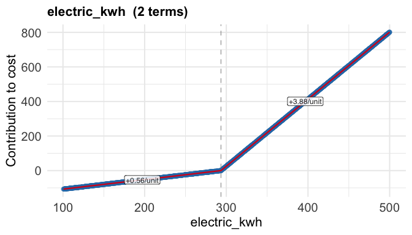

```r
idx <- which(gf$g_j == 1 & gf$g_f == 0)[1]
plot_g_function(result, idx)
```

### 1st-Degree: Factor Variable (d = 0)

A categorical variable contributes a fixed offset for each level. No continuous axis is needed — the contribution is a single value per category:

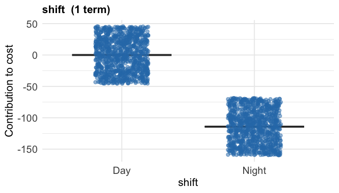

```r
idx <- which(gf$g_j == 1 & gf$g_f == 1)[1]
plot_g_function(result, idx)
```

### 2nd-Degree: No Factors (d = 2)

Two numeric variables interacting. Shown as a filled contour — the color represents the joint contribution to cost:

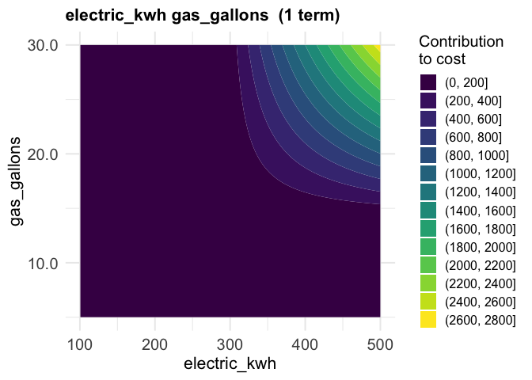

```r
idx <- which(gf$g_j == 2 & gf$g_f == 0)[1]
plot_g_contour(result, idx)
```

### 2nd-Degree: 1 Factor (d = 1)

Here `electric_kwh` (numeric) interacts with `shift` (a factor with levels Day and Night). The factor variable acts as an indicator function that selects which hinge terms are active, reducing the dimension from $d = 2$ to $d = 1$. Instead of a 3D surface, the plot shows a separate piecewise-linear contribution curve for each factor level on a single 2D chart — `electric_kwh` on the x-axis and its contribution to `cost` on the y-axis.

**Note:** This plot shows only the **interaction** contribution — i.e., how the effect of `electric_kwh` *differs* between Day and Night shifts. The main effect of `electric_kwh` (which increases cost for all shifts) is captured separately in the 1st-degree g-function above. The total effect on cost is the sum of both.

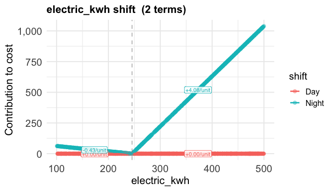

```r
idx <- which(gf$g_j == 2 & gf$g_f == 1)[1]
plot_g_function(result, idx)
```

### 2nd-Degree: 2 Factors (d = 0)

Here `region` (North/South/West) interacts with `shift` (Day/Night). Both variables are factors, so $d = 2 - 2 = 0$ — there is no continuous axis at all. The heatmap below shows the interaction contribution for every region–shift combination. South-Night has the largest value because Southern plants — lacking night-shift infrastructure — pay a steep premium that the main effects of region and shift alone do not capture. North-Night shows a moderate premium (winter heating loads at night). West cells show zero because West is the reference level; Day cells show zero because Day is the reference level.

**Note:** This plot shows only the **non-additive** part of the cost — the amount beyond what the separate main effects of `region` and `shift` would predict. A cell reading $0 does not mean that combination is free; it means the cost for that combination equals the sum of its individual main effects (shown in the 1st-degree g-functions above).

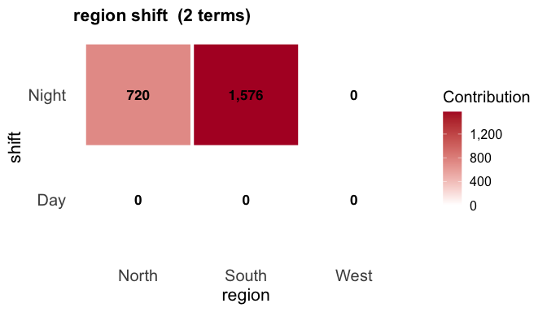

```r
idx <- which(gf$g_j == 2 & gf$g_f == 2)[1]
plot_g_function(result, idx)
```

### 3rd-Degree: No Factors (d = 3)

Here `gas_gallons`, `electric_kwh`, and `labor_hours` all interact. With three numeric variables and no factors, $d = 3 - 0 = 3$. Since we can only display two dimensions at a time, `earthUI` shows a contour of two variables with the third fixed at a representative value. To see the full behavior, generate multiple plots at different fixed values of the third variable:

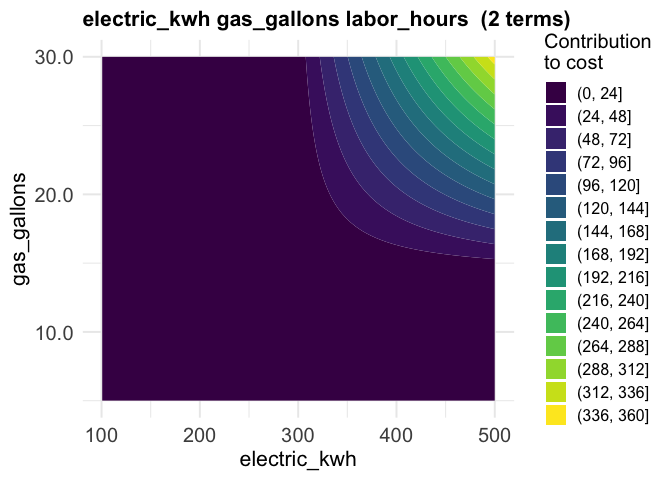

```r
idx <- which(gf$g_j == 3 & gf$g_f == 0)[1]
if (!is.na(idx)) plot_g_contour(result, idx)
```

### 3rd-Degree: 1 Factor (d = 2)

Here `gas_gallons` and `electric_kwh` (numeric) interact with `region` (North/South/West). The factor reduces the dimension from $d = 3$ to $d = 2$, so `earthUI` shows a separate contour for each factor level present in the model.

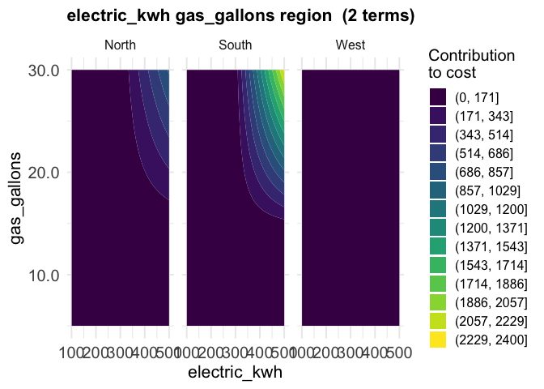

```r
idx <- which(gf$g_j == 3 & gf$g_f == 1)[1]
if (!is.na(idx)) plot_g_contour(result, idx)
```

### 3rd-Degree: 2 Factors (d = 1)

Here `gas_gallons` (numeric) interacts with both `region` (North/South/West) and `shift` (Day/Night). Two factors reduce the dimension from $d = 3$ to $d = 1$, producing a 2D line plot with `gas_gallons` on the x-axis. Each factor combination gets its own line — color encodes `region`, line style encodes `shift`.

Both Night-shift lines rise steeply with gas consumption: North-Night and South-Night show substantial per-gallon surcharges. North-Night reflects winter heating costs that compound with nighttime gas draw; South-Night reflects emergency off-site gas deliveries on Night shifts. All Day-shift lines and West-Night sit at zero — West is the reference level and Day is the reference shift, so their three-way interaction is fully captured by the lower-order terms.

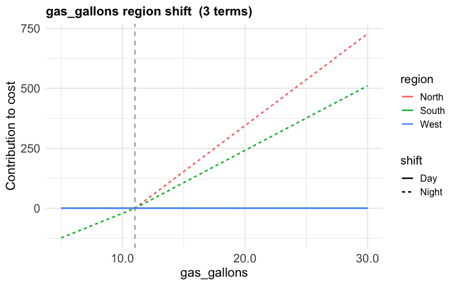

```r
idx <- which(gf$g_j == 3 & gf$g_f == 2)[1]
if (!is.na(idx)) plot_g_function(result, idx)
```

### 3rd-Degree: 3 Factors (d = 0)

Here `product` (Canned/Dried/Frozen), `region` (North/South/West), and `shift` (Day/Night) all interact. Three factors reduce the dimension from $d = 3$ to $d = 0$ — there is no continuous axis. `earthUI` shows faceted heatmaps: the first two factors form the grid of each panel, and the third factor creates the facets.

The Day panel is entirely zero — the three-way interaction premium only kicks in on Night shifts. The Night panel reveals the costly combinations: Frozen product at a Southern plant tops the chart because blast-freezer compressors fighting warm ambient air at peak nighttime rates compound all three factors simultaneously. Frozen-North-Night shows a substantial premium as well — blast-freezer compressors fighting extreme winter cold at night. Canned product, Dried product, and Western plants show zero because Canned and West are reference levels and the Dried signal was too weak to survive pruning.

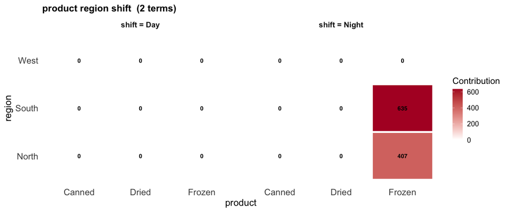

```r
idx <- which(gf$g_j == 3 & gf$g_f == 3)[1]
if (!is.na(idx)) plot_g_function(result, idx)
```

### Visualization Summary for 3rd-Degree Terms

Third-degree terms are uncommon but require careful visualization:

| Factors | d | Visualization |
| --- | --- | --- |
| 0 | 3 | 3D surface of 2 variables, fixing the 3rd at representative values |
| 1 (N levels) | 2 | N separate contours or surfaces, one per factor level |
| 2 (L $\times$ M levels) | 1 | 2D line plot of the numeric variable; color = first factor, line style = second factor |
| 3 (K $\times$ L $\times$ M) | 0 | Faceted heatmaps: two factors form the grid, third factor creates facet panels |

## Reference

Craytor, W.B. (2025). *Residual Constraint Approach (RCA)*. Zenodo. DOI: [10.5281/zenodo.14970844](https://zenodo.org/records/14970844)

[^1]: MARS is a registered trademark of Minitab, LLC.